# Моментум-стратегии и reality check Бразилия (данные с нулями)

> Количество исследумых компаний – **66**

> Период отслеживания менялся от **1** до **12** месяцев

> Период ожидания менялся от **0** до **8** недель

> Период инвестирования менялся от **1** до **12** месяцев

## 1. Моментум стратегии при равных весах. Ранжирование по средней доходности (бенчмарк 6% годовых - только для reality check)

> Всего было рассмотрено **5184** стратегий

#### **Таблица 1. Все стратегии**

|  | mean | t | p-value | hist_per | moment_per | invest_per | percent | Amount_of_negative |
| --- | --- | --- | --- | --- | --- | --- | --- | --- |
| 1 | -0.000261 | 0.114781 | 0.908883 | 4 | 0 | 4 | 0.5 | 48 |
| 2 | -0.001141 | 0.651682 | 0.516324 | 4 | 0 | 8 | 0.5 | 44 |
| 3 | -0.000292 | 0.175628 | 0.860994 | 4 | 0 | 12 | 0.5 | 47 |
| 4 | -0.000665 | 0.419688 | 0.675748 | 4 | 0 | 16 | 0.5 | 45 |
| 5 | -0.000141 | 0.102823 | 0.91834 | 4 | 0 | 20 | 0.5 | 48 |
| 6 | -0.000219 | 0.193426 | 0.847076 | 4 | 0 | 24 | 0.5 | 46 |
| 7 | -0.000545 | 0.583967 | 0.560754 | 4 | 0 | 28 | 0.5 | 50 |
| 8 | -0.000558 | 0.64876 | 0.518202 | 4 | 0 | 32 | 0.5 | 46 |
| 9 | -8.3e-05 | 0.09729 | 0.92272 | 4 | 0 | 36 | 0.5 | 41 |
| 10 | 0.000182 | 0.227602 | 0.82049 | 4 | 0 | 40 | 0.5 | 39 |

[output cut: 5174 more lines]

#### **Рисунок 1.**

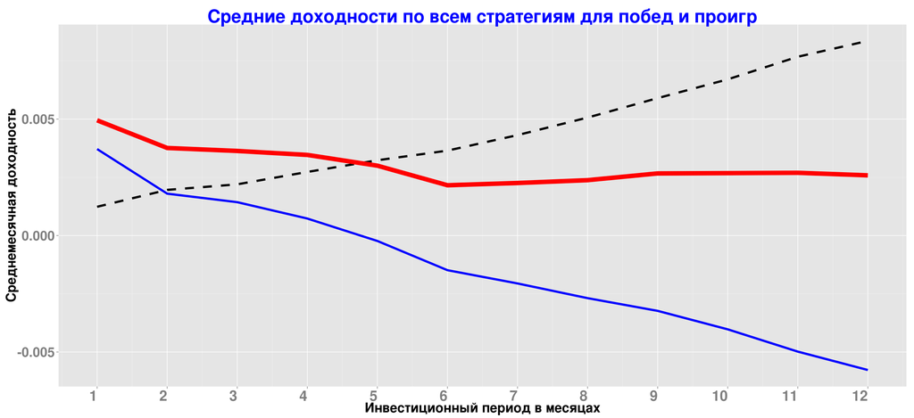

#### **Таблица 2. Агрегированные по всем стратегиям доходности победителей и проигравших**

|  | invest.per | aggr.winner | aggr.loser | delta |
| --- | --- | --- | --- | --- |
| 1 | 1 | 0.0049 | 0.0037 | 0.0012 |
| 2 | 2 | 0.0038 | 0.0018 | 0.002 |
| 3 | 3 | 0.0036 | 0.0014 | 0.0022 |
| 4 | 4 | 0.0035 | 0.0007 | 0.0027 |
| 5 | 5 | 0.003 | -0.0002 | 0.0032 |
| 6 | 6 | 0.0022 | -0.0015 | 0.0036 |
| 7 | 7 | 0.0023 | -0.0021 | 0.0043 |
| 8 | 8 | 0.0024 | -0.0027 | 0.0051 |
| 9 | 9 | 0.0027 | -0.0032 | 0.0059 |
| 10 | 10 | 0.0027 | -0.004 | 0.0067 |

[output cut: 2 more lines]

> Лучшая по средней доходности стратегия дает среднемесячную доходность **1.68** **%** и имеет параметры: период отбора – **11** месяцев, период ожидания – **8** недель, период инвестирования – **1** месяцев, процентиль – **0.1**

> Bootstrap p-value равен **0.61**

> Всего портфелей у лучшей стратегии – **88** Количество отрицательных доходностей у лучшей стратегии – **37** ( **42.05%** )

#### **Рисунок 2.**

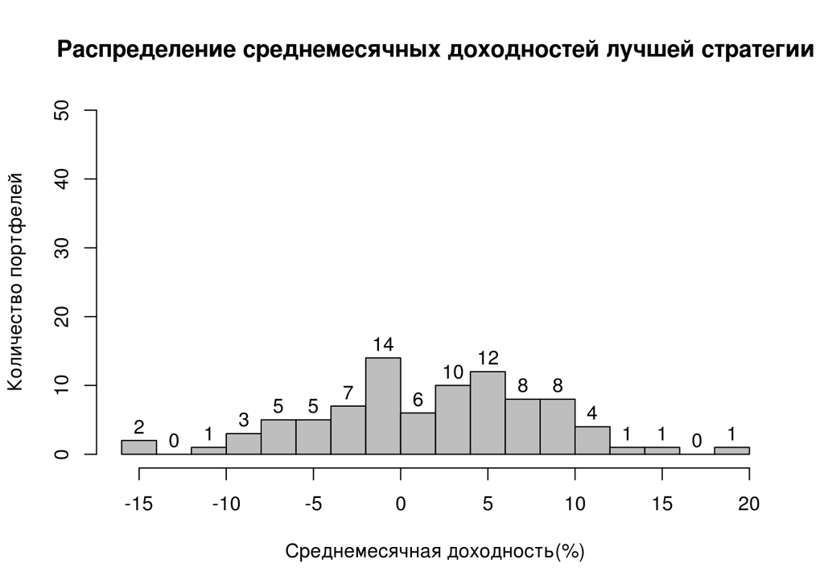

#### **Рисунок 3. (вертикальные пунктирные линии - начало нового года)**

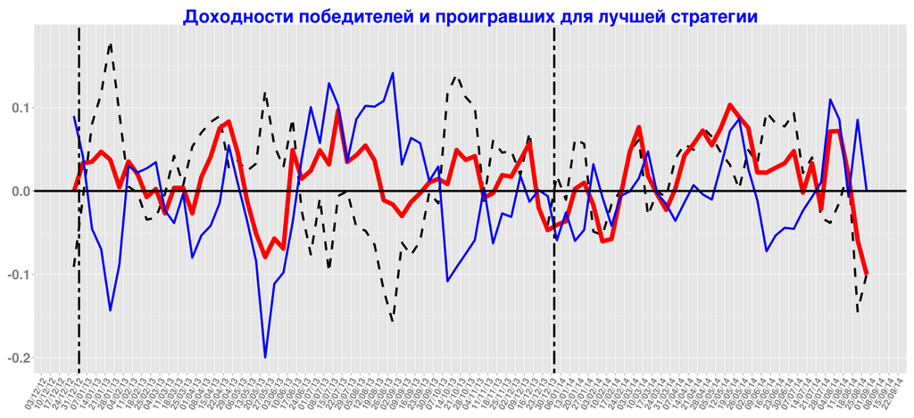

#### **Таблица 3. Доходности победителей и проигравших для лучшей стратегии**

|  | date | Win_portf | Los_portf | Win_Los |
| --- | --- | --- | --- | --- |
| 1 | 2012-12-28 | -0.0011 | 0.09 | -0.0911 |
| 2 | 2013-01-04 | 0.0334 | 0.0415 | -0.0081 |
| 3 | 2013-01-11 | 0.0351 | -0.0455 | 0.0807 |
| 4 | 2013-01-18 | 0.0471 | -0.0697 | 0.1168 |
| 5 | 2013-01-25 | 0.0375 | -0.1432 | 0.1808 |
| 6 | 2013-02-01 | 0.0046 | -0.0883 | 0.0929 |
| 7 | 2013-02-08 | 0.0354 | 0.03 | 0.0054 |
| 8 | 2013-02-15 | 0.0199 | 0.0222 | -0.0023 |
| 9 | 2013-02-22 | -0.0072 | 0.0271 | -0.0344 |
| 10 | 2013-03-01 | 0.0024 | 0.0345 | -0.0321 |

[output cut: 78 more lines]

### **Вхождение в победителей и проигравших для лучшей стратегии**

#### **Рисунок 4.**

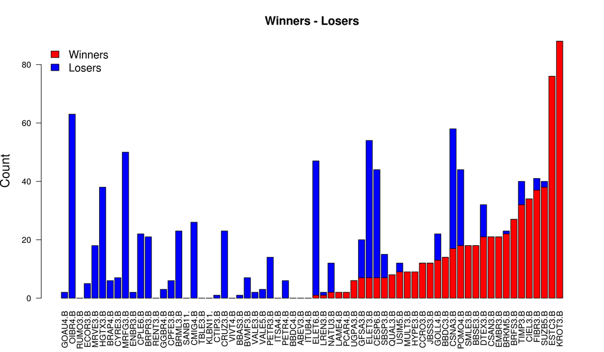

#### **Рисунок 5.**

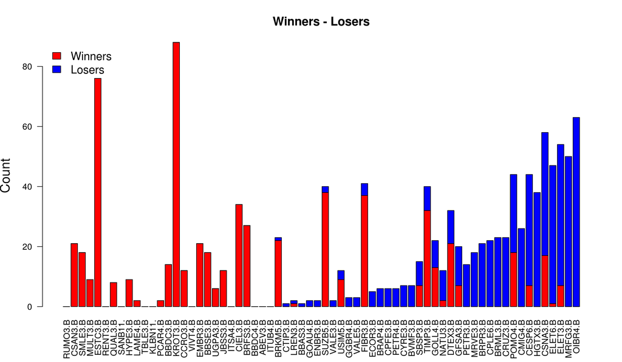

#### **Таблица 4. Вхождение компаний в победители и проигравшие для лучшей по средней доходности стратегии**

|  | Ticket | In_winners | In_losers |
| --- | --- | --- | --- |
| 1 | GOLL4.BS.Equity | 13 | 9 |
| 2 | GOAU4.BS.Equity | 0 | 2 |
| 3 | GFSA3.BS.Equity | 7 | 13 |
| 4 | OIBR4.BS.Equity | 0 | 63 |
| 5 | RUMO3.BS.Equity | 0 | 0 |
| 6 | ELET3.BS.Equity | 7 | 47 |
| 7 | POMO4.BS.Equity | 18 | 26 |
| 8 | ECOR3.BS.Equity | 0 | 5 |
| 9 | USIM5.BS.Equity | 9 | 3 |
| 10 | DTEX3.BS.Equity | 21 | 11 |

[output cut: 56 more lines]

## 2. Моментум стратегии при равных весах. Ранжирование по t-статистике (бенчмарк 6% годовых - только для reality check)

> Лучшая по t-статистике стратегия дает среднемесячную доходность **1.23** **%** и имеет параметры: период отбора – **7** месяцев, период ожидания – **3** недель, период инвестирования – **12** месяцев, процентиль – **0.2**

> Bootstrap p-value равен **0.182**

> Всего портфелей у лучшей по t-статистике стратегии – **88** Количество отрицательных доходностей у лучшей по t-статистике стратегии – **2** ( **2.27%** )

#### **Рисунок 6.**

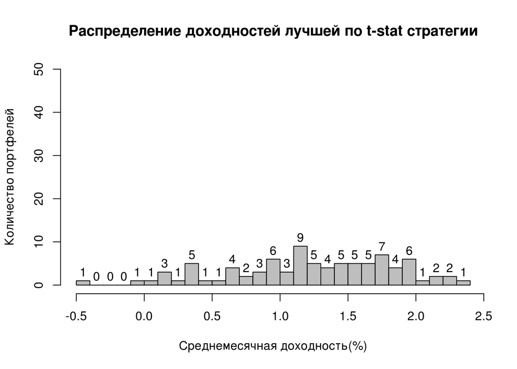

#### **Рисунок 7. (вертикальные пунктирные линии - начало нового года)**

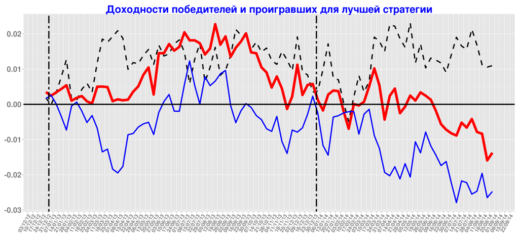

#### **Таблица 5. Доходности победителей и проигравших для лучшей стратегии**

|  | date | Win_portf | Los_portf | Win_Los |
| --- | --- | --- | --- | --- |
| 1 | 2012-12-28 | 0.0035 | 0.0016 | 0.0018 |
| 2 | 2013-01-04 | 0.0024 | 0.0026 | -0.0002 |
| 3 | 2013-01-11 | 0.0034 | 0.0001 | 0.0033 |
| 4 | 2013-01-18 | 0.0044 | -0.0034 | 0.0078 |
| 5 | 2013-01-25 | 0.0054 | -0.0073 | 0.0127 |
| 6 | 2013-02-01 | 0.001 | -0.0005 | 0.0015 |
| 7 | 2013-02-08 | 0.0018 | 0.0006 | 0.0012 |
| 8 | 2013-02-15 | 0.0023 | -0.0019 | 0.0043 |
| 9 | 2013-02-22 | 0.0009 | -0.0052 | 0.006 |
| 10 | 2013-03-01 | 0.0002 | -0.0032 | 0.0034 |

[output cut: 78 more lines]

### **Вхождение в победителей и проигравших для лучшей стратегии**

#### **Рисунок 8.**

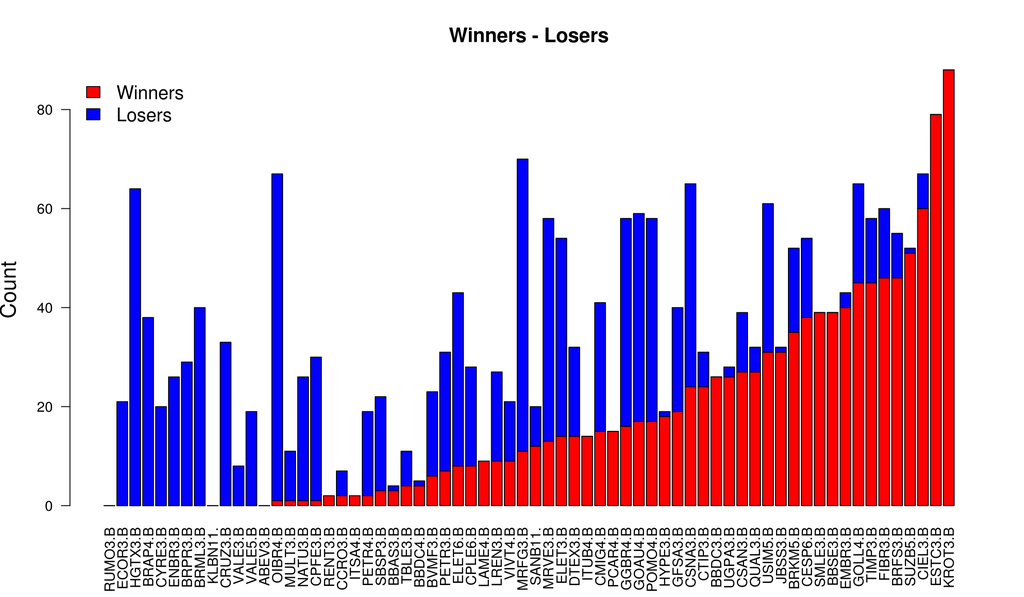

#### **Рисунок 9.**

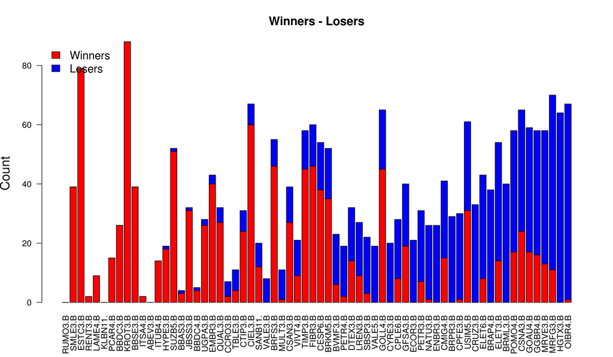

#### **Таблица 6. Вхождение компаний в победители и проигравшие для лучшей по t-статистике стратегии**

|  | Ticket | In_winners | In_losers |
| --- | --- | --- | --- |
| 1 | GOLL4.BS.Equity | 45 | 20 |
| 2 | GOAU4.BS.Equity | 17 | 42 |
| 3 | GFSA3.BS.Equity | 19 | 21 |
| 4 | OIBR4.BS.Equity | 1 | 66 |
| 5 | RUMO3.BS.Equity | 0 | 0 |
| 6 | ELET3.BS.Equity | 14 | 40 |
| 7 | POMO4.BS.Equity | 17 | 41 |
| 8 | ECOR3.BS.Equity | 0 | 21 |
| 9 | USIM5.BS.Equity | 31 | 30 |
| 10 | DTEX3.BS.Equity | 14 | 18 |

[output cut: 56 more lines]